# University Buffet

**Jenish Vinodbhai Dhaduk**

**Student ID- 989354198**

Project Title - University Buffet

Contents of the Project  
1. Objective  
2. Data Exploration  
3. Dendrogram  
4. Step-by-step K-means  
5. Sklearn.cluster  
6. Pediction  
7. 2D prediction mesh  
8. Summary(Recommendations)

## 1. Objective.

The University of the Pacific have arranged "ALL-YOU-CAN-EAT" buffet and wish to have all the students at this buffet. So University have decide to run a coupn campaigns that sends targeted emails to the students which are likely to encourage them to come. The university has hired me to create a recommendation engine for email coupon campaigns.

To create an engine, a detailed analysis of the dataset needs to be carried out. This dataset includes information on food choices, nutrition, preferences, childhood favorites, and other information from college students. Data is raw and uncleaned. It might require lot of Cleaning in the process.

```python
import matplotlib.pyplot as plt
from matplotlib.colors import ListedColormap
from sklearn import datasets
from sklearn.cluster import KMeans
import sklearn.metrics as sm
from scipy.cluster.hierarchy import dendrogram, linkage, leaves_list
from sklearn.cluster import KMeans
from sklearn.preprocessing import MinMaxScaler
from mpl_toolkits.mplot3d import Axes3D


import pandas as pd
import numpy as np

# Set some pandas options
pd.set_option('display.notebook_repr_html', False)
pd.set_option('display.max_rows', 60)
pd.set_option('display.max_columns', 60)
pd.set_option('display.width', 1000)
%matplotlib inline
```

All the necessary library and packages are insatlled and imported.

```python
foodmain=pd.read_csv("food_coded.csv")
```

The dataset "food_coded" is read into the notebook.

# 2. Data Exploration

### 2.1 Displaing the rows of the dataset

```python
foodrows=len(foodmain.index)
foodrows
```

```
125
```

There are 125 rowsin the dataset **food_coded.**

### 2.2 Displaying the columns of the dataset

```python
foodcolumns=len(foodmain.columns)
foodcolumns
```

```
61
```

There are 61 columns in the dataset **food_coded**.

### 2.3 Displaying Total open ended columns of the dataset

```python
openendedcolumns = ['comfort_food','comfort_food_reasons','diet_current','eating_changes','father_profession','mother_profession','fav_cuisine','food_childhood','healthy_meal','ideal_diet','meals_dinner_friend','type_sports']
foodex = foodmain.drop(openendedcolumns,axis=1)
foodclosecolumns=len(foodex.columns)
foodclosecolumns
```

```
49
```

All the open ended columns of the dataset are selected and is droped to form another dataset. There were total 12 openended columns.

### 2.4 Displaying the total number of cuisine in the dataset

```python
a = set(foodex["cuisine"])
len(a)
```

```
23
```

There are **23** different cuisisne that student collectively admired.

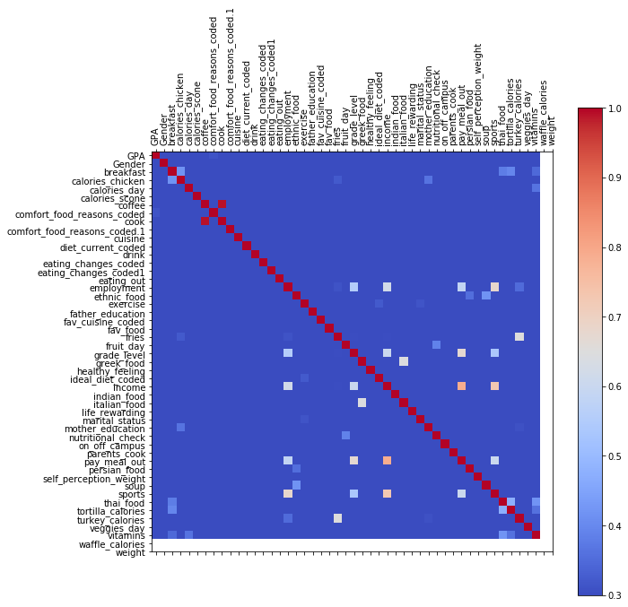

```python
corr = foodex.corr()
fig = plt.figure(figsize=(10, 10))
ax = fig.add_subplot(111)
cax = ax.matshow(corr,cmap='coolwarm', vmin=0.3,vmax=1)
fig.colorbar(cax)
ticks = np.arange(0,len(foodex.columns),1)
ax.set_xticks(ticks)
plt.xticks(rotation=90)
ax.set_yticks(ticks)
ax.set_xticklabels(foodex.columns)
ax.set_yticklabels(foodex.columns)
plt.show()
#foodex.corr()
```

The above correlation displays the correlations among the different columns of the dataset which can be helpful to identified most affected variable to Fries,coffee,soup whose photos can be used to display on the coupon.

# 3. Dendogram

Select 3 to 5 columns of your choice, Create a dendrogram and make a determination on the k number of clusters

```python
food= pd.concat([foodmain["thai_food"].astype(float),
                          foodmain["ethnic_food"].astype(float),
                         foodmain["cook"].astype(float)],axis =1)
food['cook'].fillna(3, inplace=True)
food['thai_food'].fillna(3, inplace=True)
food['ethnic_food'].fillna(3, inplace=True)
```

Three most related columns are taken out to form a new dataframe "food". Nan values are replaced with "Netural" that is number "3" on code_book food.

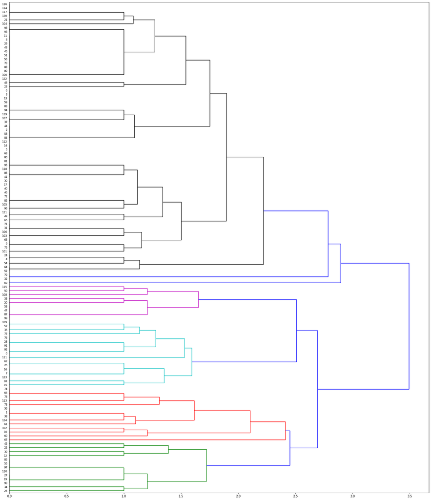

```python
Z = linkage(food, 'average')
plt.figure(figsize=(25, 30))
D = dendrogram(Z=Z, orientation="right", leaf_font_size=9, labels = food.index)
```

Above is a dendogram of dataframe food.

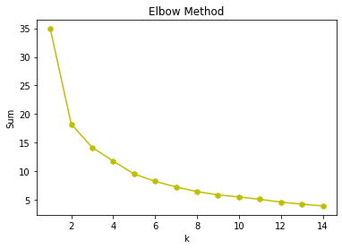

```python
dmms=MinMaxScaler()
dmms.fit(food)
dtrans=dmms.transform(food)

dsum=[]
K=range(1,15)
for k in K:
    dkm=KMeans(n_clusters=k)
    dkm=dkm.fit(dtrans)
    dsum.append(dkm.inertia_)

plt.plot(K,dsum,'yh-')
plt.xlabel('k')
plt.ylabel('Sum')
plt.title('Elbow Method')
plt.show()
```

The above figue use to identify the number of clusters in the selected dataframe.

## 3. step by step k means

```python
studentid = range(0, len(food))
food['studentid']=studentid

food.tail(5)
```

```
     thai_food  ethnic_food  cook  studentid
120        5.0          4.0   3.0        120
121        4.0          3.0   3.0        121
122        5.0          5.0   3.0        122
123        1.0          2.0   3.0        123
124        2.0          3.0   3.0        124
```

Adding "studentid" to the dataframe "food" which is extracted from "foodmain" dataset by taking three columns "thai_food","ethnic_food","cook". Now all the operations will be perform on "food" dataframe

### Create function

```python
def kmeans(centroid1,centroid2,centroid3,food,k):
    food["Dist_C1"] = np.sqrt((food.thai_food - centroid1[0])**2
                             + (food.ethnic_food - centroid1[1])**2+(food.cook - centroid1[2])**2)
    food["Dist_C2"] = np.sqrt((food.thai_food - centroid2[0])**2
                             + (food.ethnic_food - centroid2[1])**2+(food.cook - centroid2[2])**2)
    food["Dist_C3"] = np.sqrt((food.thai_food - centroid3[0])**2
                             + (food.ethnic_food - centroid3[1])**2+(food.cook - centroid3[2])**2)
###
    food["Association"] = np.where(
    (food.Dist_C1 < food.Dist_C2) &
    (food.Dist_C1 < food.Dist_C3), 1,
    np.where((food.Dist_C2 < food.Dist_C1) &
    (food.Dist_C2 < food.Dist_C3) , 2, 3))

###
   # food[food.Association == 1]
    #food[food.Association == 2]
    #food[food.Association == 3].head(1)

    centroi1 = food[food.Association == 1][["thai_food","ethnic_food","cook"]].mean()
    centroi2 = food[food.Association == 2][["thai_food","ethnic_food","cook"]].mean()
    centroi3 = food[food.Association == 3][["thai_food","ethnic_food","cook"]].mean()

    forcluster1=food[food.Association == 1]
    cluster_1 = forcluster1['studentid'].values
    cluster_1

    forcluster2=food[food.Association == 2]
    cluster_2 = forcluster2['studentid'].values
    cluster_2

    forcluster3=food[food.Association == 3]
    cluster_3 = forcluster3['studentid'].values
    cluster_3

    return(centroi1,centroi2,centroi3,cluster_1,cluster_2,cluster_3)
```

A kmeans() function is created that accepts a "dataframe" and "k" as parameters, and returns the clusters created.

## 1st iteration

```python
oldcent1 = np.array([2.0,2.0,2.0])
oldcent2 = np.array([2.0,4.0,1.0])
oldcent3 = np.array([4.0,2.0,3.0])
dataframe = food
x = kmeans(oldcent1,oldcent2,oldcent3,dataframe,k)
print(x)
```

```
(thai_food      1.466667
ethnic_food    2.300000
cook           2.866667
dtype: float64, thai_food      3.24
ethnic_food    4.56
cook           1.76
dtype: float64, thai_food      4.171429
ethnic_food    4.071429
cook           3.128571
dtype: float64, array([  0,   7,  15,  16,  18,  20,  26,  28,  33,  35,  47,  50,  53,
        57,  62,  66,  74,  76,  77,  78,  87,  91,  92,  99, 109, 111,
       113, 115, 123, 124]), array([  1,   2,   4,  10,  24,  31,  36,  38,  44,  52,  54,  58,  60,
        61,  64,  67,  71,  73,  84,  96, 101, 102, 103, 106, 112]), array([  3,   5,   6,   8,   9,  11,  12,  13,  14,  17,  19,  21,  22,
        23,  25,  27,  29,  30,  32,  34,  37,  39,  40,  41,  42,  43,
        45,  46,  48,  49,  51,  55,  56,  59,  63,  65,  68,  69,  70,
        72,  75,  79,  80,  81,  82,  83,  85,  86,  88,  89,  90,  93,
        94,  95,  97,  98, 100, 104, 105, 107, 108, 110, 114, 116, 117,
       118, 119, 120, 121, 122]))
```

The 1st iteration is done using function Kmeans() which takes parameters including centroids, dataframe and number of cluster. It gives the cluster classification after 1st iterartion as well.

## 2nd iteration

```python
y = kmeans(x[0],x[1],x[2],dataframe,k)
print(y)
```

```
(thai_food      1.500000
ethnic_food    2.382353
cook           3.000000
dtype: float64, thai_food      3.52
ethnic_food    4.44
cook           1.60
dtype: float64, thai_food      4.212121
ethnic_food    4.181818
cook           3.136364
dtype: float64, array([  0,   1,   7,  15,  16,  18,  20,  25,  26,  28,  33,  34,  35,
        36,  38,  47,  50,  53,  57,  62,  73,  76,  77,  87,  91,  92,
        99, 108, 109, 111, 113, 115, 123, 124]), array([  2,   4,  10,  24,  31,  41,  44,  52,  54,  58,  60,  61,  64,
        66,  71,  74,  78,  84,  86,  96, 101, 102, 103, 106, 112]), array([  3,   5,   6,   8,   9,  11,  12,  13,  14,  17,  19,  21,  22,
        23,  27,  29,  30,  32,  37,  39,  40,  42,  43,  45,  46,  48,
        49,  51,  55,  56,  59,  63,  65,  67,  68,  69,  70,  72,  75,
        79,  80,  81,  82,  83,  85,  88,  89,  90,  93,  94,  95,  97,
        98, 100, 104, 105, 107, 110, 114, 116, 117, 118, 119, 120, 121,
       122]))
```

The 2nd iteration is done using function Kmeans() which takes parameters including centroids, dataframe and number of cluster. It gives the cluster classification after 2nd iterartion as well.

## 3rd iteration

```python
z = kmeans(y[0],y[1],y[2],dataframe,k)
print(z)
```

```
(thai_food      1.657895
ethnic_food    2.447368
cook           3.000000
dtype: float64, thai_food      3.56
ethnic_food    4.36
cook           1.56
dtype: float64, thai_food      4.274194
ethnic_food    4.290323
cook           3.161290
dtype: float64, array([  0,   1,   7,  15,  16,  18,  20,  25,  26,  28,  33,  34,  35,
        36,  38,  47,  50,  53,  55,  57,  62,  73,  76,  77,  85,  87,
        91,  92,  97,  99, 108, 109, 110, 111, 113, 115, 123, 124]), array([  2,   4,  10,  24,  31,  41,  44,  52,  54,  58,  60,  61,  64,
        65,  66,  71,  74,  78,  84,  86,  96, 102, 103, 106, 112]), array([  3,   5,   6,   8,   9,  11,  12,  13,  14,  17,  19,  21,  22,
        23,  27,  29,  30,  32,  37,  39,  40,  42,  43,  45,  46,  48,
        49,  51,  56,  59,  63,  67,  68,  69,  70,  72,  75,  79,  80,
        81,  82,  83,  88,  89,  90,  93,  94,  95,  98, 100, 101, 104,
       105, 107, 114, 116, 117, 118, 119, 120, 121, 122]))
```

The 3rd iteration is done using function Kmeans() which takes parameters including centroids, dataframe and number of cluster. It gives the cluster classification after 3rd iterartion as well.

## 4th iteration

```python
q = kmeans(z[0],z[1],z[2],dataframe,k)
print(q)
```

```
(thai_food      1.785714
ethnic_food    2.500000
cook           3.119048
dtype: float64, thai_food      3.56
ethnic_food    4.36
cook           1.56
dtype: float64, thai_food      4.362069
ethnic_food    4.379310
cook           3.086207
dtype: float64, array([  0,   1,   7,  15,  16,  18,  19,  20,  25,  26,  27,  28,  33,
        34,  35,  36,  38,  39,  47,  50,  53,  55,  57,  62,  73,  76,
        77,  85,  87,  90,  91,  92,  97,  99, 108, 109, 110, 111, 113,
       115, 123, 124]), array([  2,   4,  10,  24,  31,  41,  44,  52,  54,  58,  60,  61,  64,
        65,  66,  71,  74,  78,  84,  86,  96, 102, 103, 106, 112]), array([  3,   5,   6,   8,   9,  11,  12,  13,  14,  17,  21,  22,  23,
        29,  30,  32,  37,  40,  42,  43,  45,  46,  48,  49,  51,  56,
        59,  63,  67,  68,  69,  70,  72,  75,  79,  80,  81,  82,  83,
        88,  89,  93,  94,  95,  98, 100, 101, 104, 105, 107, 114, 116,
       117, 118, 119, 120, 121, 122]))
```

The 4th iteration is done using function Kmeans() which takes parameters including centroids, dataframe and number of cluster. It gives the cluster classification after 4th iterartion as well.

## 5th iteration

```python
p = kmeans(q[0],q[1],q[2],dataframe,k)
print (p)
```

```
(thai_food      1.780488
ethnic_food    2.487805
cook           3.170732
dtype: float64, thai_food      3.500000
ethnic_food    4.307692
cook           1.538462
dtype: float64, thai_food      4.362069
ethnic_food    4.379310
cook           3.086207
dtype: float64, array([  0,   1,   7,  15,  16,  18,  19,  20,  25,  26,  27,  28,  33,
        34,  35,  36,  38,  39,  47,  50,  53,  55,  57,  62,  76,  77,
        85,  87,  90,  91,  92,  97,  99, 108, 109, 110, 111, 113, 115,
       123, 124]), array([  2,   4,  10,  24,  31,  41,  44,  52,  54,  58,  60,  61,  64,
        65,  66,  71,  73,  74,  78,  84,  86,  96, 102, 103, 106, 112]), array([  3,   5,   6,   8,   9,  11,  12,  13,  14,  17,  21,  22,  23,
        29,  30,  32,  37,  40,  42,  43,  45,  46,  48,  49,  51,  56,
        59,  63,  67,  68,  69,  70,  72,  75,  79,  80,  81,  82,  83,
        88,  89,  93,  94,  95,  98, 100, 101, 104, 105, 107, 114, 116,
       117, 118, 119, 120, 121, 122]))
```

The 5th iteration is done using function Kmeans() which takes parameters including centroids, dataframe and number of cluster. It gives the cluster classification after 5th iterartion as well.

## 6th iteration

```python
w = kmeans(p[0],p[1],p[2],dataframe,k)
print(w)
```

```
(thai_food      1.780488
ethnic_food    2.487805
cook           3.170732
dtype: float64, thai_food      3.500000
ethnic_food    4.307692
cook           1.538462
dtype: float64, thai_food      4.362069
ethnic_food    4.379310
cook           3.086207
dtype: float64, array([  0,   1,   7,  15,  16,  18,  19,  20,  25,  26,  27,  28,  33,
        34,  35,  36,  38,  39,  47,  50,  53,  55,  57,  62,  76,  77,
        85,  87,  90,  91,  92,  97,  99, 108, 109, 110, 111, 113, 115,
       123, 124]), array([  2,   4,  10,  24,  31,  41,  44,  52,  54,  58,  60,  61,  64,
        65,  66,  71,  73,  74,  78,  84,  86,  96, 102, 103, 106, 112]), array([  3,   5,   6,   8,   9,  11,  12,  13,  14,  17,  21,  22,  23,
        29,  30,  32,  37,  40,  42,  43,  45,  46,  48,  49,  51,  56,
        59,  63,  67,  68,  69,  70,  72,  75,  79,  80,  81,  82,  83,
        88,  89,  93,  94,  95,  98, 100, 101, 104, 105, 107, 114, 116,
       117, 118, 119, 120, 121, 122]))
```

The 6th iteration is done using function Kmeans() which takes parameters including centroids, dataframe and number of cluster. It gives the cluster classification after 6th iterartion as well. The centroids and the clusters didnt seems to be changing after 6th iteration. So the final clusters have been prepared.

```python
forcluster1=food[food.Association == 1]
cluster_1 = forcluster1['studentid'].values
cluster_1
```

```
array([  0,   1,   7,  15,  16,  18,  19,  20,  25,  26,  27,  28,  33,
        34,  35,  36,  38,  39,  47,  50,  53,  55,  57,  62,  76,  77,
        85,  87,  90,  91,  92,  97,  99, 108, 109, 110, 111, 113, 115,
       123, 124])
```

The above values are the "studentid" of students from Cluster1.

```python
forcluster2=food[food.Association == 2]
cluster_2 = forcluster2['studentid'].values
cluster_2
```

```
array([  2,   4,  10,  24,  31,  41,  44,  52,  54,  58,  60,  61,  64,
        65,  66,  71,  73,  74,  78,  84,  86,  96, 102, 103, 106, 112])
```

The above values are the "studentid" of students from Cluster2.

```python
forcluster3=food[food.Association == 3]
cluster_3 = forcluster3['studentid'].values
cluster_3
```

```
array([  3,   5,   6,   8,   9,  11,  12,  13,  14,  17,  21,  22,  23,
        29,  30,  32,  37,  40,  42,  43,  45,  46,  48,  49,  51,  56,
        59,  63,  67,  68,  69,  70,  72,  75,  79,  80,  81,  82,  83,
        88,  89,  93,  94,  95,  98, 100, 101, 104, 105, 107, 114, 116,
       117, 118, 119, 120, 121, 122])
```

The above values are the "studentid" of students from Cluster3.

## 5 sklearn.cluster

[figure not shown]

```python
model = KMeans(n_clusters = 3)
k=3
model.fit(food)
model.labels_
fig = plt.figure(figsize=(15, 15))
ax = fig.add_subplot(111, projection='3d')

ax.scatter(xs = food.thai_food, ys = food.cook, zs = food.ethnic_food, c = model.labels_,
          s = 180, depthshade = False)

plt.title('K Mean Classification')
for x, y, z, l in zip( food.thai_food,food.cook, food.ethnic_food,food.index):
    ax.text(x, y, z, l)

ax.set_ylabel('food.thai_food')
ax.set_xlabel('food.cook')
ax.set_zlabel('food.ethnic_food')


plt.show()
```

The above graph shows the three clusters but this time using the sklearn.cluster library.

```python
food2= pd.concat([food["thai_food"].astype(float),
                          food["ethnic_food"].astype(float),
                         food["cook"].astype(float)], axis =1)
food2['cook'].fillna(3, inplace=True)
food2['thai_food'].fillna(3, inplace=True)
food2['ethnic_food'].fillna(3, inplace=True)




food2=food.loc[:,['thai_food','cook','ethnic_food']]
model= KMeans(n_clusters = 3)
model.fit(food2)
model.labels_
```

```
array([1, 2, 0, 0, 0, 0, 0, 1, 0, 0, 2, 0, 2, 0, 0, 1, 1, 2, 1, 2, 1, 0,
       2, 0, 0, 1, 1, 2, 1, 0, 2, 0, 0, 1, 1, 1, 2, 0, 2, 2, 2, 0, 2, 0,
       0, 0, 2, 1, 0, 2, 1, 0, 2, 1, 0, 2, 0, 1, 0, 0, 2, 2, 1, 0, 2, 2,
       2, 2, 0, 0, 0, 0, 2, 2, 2, 0, 1, 1, 2, 0, 0, 0, 2, 0, 0, 2, 0, 1,
       0, 0, 2, 1, 1, 0, 0, 0, 2, 2, 0, 1, 0, 2, 2, 2, 0, 2, 0, 0, 1, 1,
       2, 1, 0, 2, 0, 1, 0, 0, 0, 0, 0, 2, 0, 1, 1])
```

To predict the clusters for students a new dataframe is prepared called "food2".

## 6. Prediction

Create a function that accepts up to 3 to 5 parameters, which represent the characteristics of the student, and will print coupons according to the cluster the student belongs to. Run your algorithm 10 times with different parameters.

```python
def predict(thai,cook,ethnic):
    colormap = np.array(['cluster1','cluster2','cluster3'])
    data_class = model.predict(np.array([thai,cook,ethnic]).reshape(1, -1))[0]
    return(colormap[data_class])
```

The above function will predict the student's cluster on the basis of the three values thai_food,cook and ethnic_food.

```python
thai=[3,4,2,3,5,1,4,4,3,5]
cook=[1,2,3,4,5,1,2,3,5,5]
ethnic=[2,3,4,5,5,2,3,1,5,5]
thai=[float(i) for i in thai]
cook=[float(i) for i in cook]
ethnic=[float(i) for i in ethnic]

for i in range(0,10):
    clust=predict(thai[i],cook[i],ethnic[i])
    print(i,"number student will get coupoun belong to:")
    print(clust)
    print('-----')
```

```
0 number student will get coupoun belong to:
cluster3
-----
1 number student will get coupoun belong to:
cluster3
-----
2 number student will get coupoun belong to:
cluster3
-----
3 number student will get coupoun belong to:
cluster3
-----
4 number student will get coupoun belong to:
cluster1
-----
5 number student will get coupoun belong to:
cluster2
-----
6 number student will get coupoun belong to:
cluster3
-----
7 number student will get coupoun belong to:
cluster2
-----
8 number student will get coupoun belong to:
cluster3
-----
9 number student will get coupoun belong to:
cluster1
-----
```

The new 10 students are shown to which cluster they belong and they will be presented with same coupon like others in that same cluster.

## 7. 2D Prediction Mesh

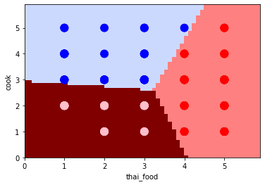

```python
food3= pd.concat([food["thai_food"].astype(float),
                         food["cook"].astype(float)], axis =1)
food3['cook'].fillna(3, inplace=True)
food3['thai_food'].fillna(3, inplace=True)
food3=food.loc[:,['thai_food','cook']]
m3= KMeans(n_clusters = 3)
m3.fit(food3)
m3.labels_


def plotMesh():
    h = 0.1
    # Create color maps
    cmap_light = ListedColormap(['maroon', '#ff8080','#ccd9ff'])
    colormap = np.array(['pink', 'red', 'blue'])

    x_min2, x_max2 = food3.thai_food.min() - 1, food3.thai_food.max() + 1
    y_min2, y_max2 = food3.cook.min() - 1, food3.cook.max() + 1
    xx2, yy2 = np.meshgrid(np.arange(x_min2, x_max2, h),np.arange(y_min2, y_max2, h))
    Z2 = m3.predict(np.c_[xx2.ravel(), yy2.ravel()])

    # Put the result into a color plot
    Z2 = Z2.reshape(xx2.shape)
    fig = plt.figure()
    plt.pcolormesh(xx2, yy2, Z2, cmap = cmap_light)

    # Plot also the training points
    plt.scatter(food3.thai_food, food3.cook, c = colormap[m3.labels_], s = 120)
    plt.xlim(xx2.min(), xx2.max())
    plt.ylim(yy2.min(), yy2.max())
    ax = fig.add_subplot(111)
    ax.set_xlabel('thai_food')
    ax.set_ylabel('cook')
plotMesh()
```

## 8. Summary(Recommendations)

From all the responses the one variable which had a stronger relationship with any of the other variable is most certain to predict the interest of the other students. So a correlation matrix is prepared to find out the strongest relation among all the variables. Three variables "cook", "thai_food", "ethnic_food" were selected as they showing a strong relationship with other variables. The student who likes Thai food also likes ethnic food and the person who cooks often might like home-made-food so such information can be useful in making coupons.

I would like to suggest based on my analysis to the university that students who like Thai_food are going to like ethnic_food and two items are enough to bring them to the buffet. Those who do find a reason to cook would likely be motivated if the image of Espresso is in their coupons instead of creamy frappuccino. Those who do some kind of sports activity will generally prefer healthy food if given an option.

The selection of the images to put on the coupon should also require some analysis as that plays a very important role in motivating students. If a student finds images of all the likable items on the coupon then he/she is more likely to come to the buffet.